# ETC3250/5250 Tutorial 3

Visualising your data and models

Author

Prof. Di Cook

Published

March 11, 2024

**Load the libraries and avoid conflicts**

```r
# Load libraries used everywhere
library(tidyverse)
library(tidymodels)
library(conflicted)
library(colorspace)
library(patchwork)
library(MASS)
library(randomForest)
library(gridExtra)
library(GGally)
library(geozoo)
library(mulgar)
conflicts_prefer(dplyr::filter)
conflicts_prefer(dplyr::select)
conflicts_prefer(dplyr::slice)
conflicts_prefer(palmerpenguins::penguins)
conflicts_prefer(tourr::flea)
```

## 🎯 Objectives

The goal for this week is for you to learn and practice visualising high-dimensional data.

## 🔧 Preparation

- Complete the quiz
- Do the reading related to week 2

## Exercises:

Open your project for this unit called `iml.Rproj`.

#### 1. Answer the following questions for this data matrix,

$$\begin{align*}
{\mathbf X} = \left[\begin{array}{rrrrr}
2 & -2 & -8 & 6 & -7 \\
6 & 6 & -4 & 9 & 6 \\
5 & 4 & 3 & -7 & 8 \\
1 & -7 & 6 & 7 & -1
\end{array}\right]
\end{align*}$$

1. Write a projection matrix which would generate a 2D projection where the first data projection has variables 1 and 4 combined equally, and the second data projection has variables 2 and 5 combined with variable 5 having greater weight.

**Solution 1**

$$\begin{align*}
{\mathbf A} = \left[\begin{array}{rr}
\frac{1}{\sqrt{2}} & 0 \\
0 & \frac{1}{\sqrt{3}} \\
0 & 0 \\
\frac{1}{\sqrt{2}} & 0 \\
0 & \frac{\sqrt{2}}{\sqrt{3}} \\
\end{array}\right]
\end{align*}$$

Note that there are several solutions for the second column, but this is one that satisfies the requirements of the question.

2. Why can’t the following matrix considered a projection matrix?

$$\begin{align*}
{\mathbf A} = \left[\begin{array}{rr}
-1/\sqrt{2} & 1/\sqrt{3} \\
0 & 0 \\
1/\sqrt{2} & 0 \\
0 & \sqrt{2}/\sqrt{3} \\
\end{array}\right]
\end{align*}$$

**Solution 2**

The columns are not orthonormal. The cross-product is not equal to 0.

#### 2. Graph Theory

1. Explain what is meant by plotting the ‘data-in-the-model-space’ and plotting the ‘model-in-the-data-space’

**Solution 3**

data-in-the-model-space corresponds to plotting the model and trying to visualise the data in this space. This is convenient as the model usually produces a low dimensional output which we can plot. Examples of this would be plotting the probabilities or predictions estimated by a model. However, a plot like this doesn’t provide an explanation of why the model is behaving the way that it is.

model-in-the-data-space corresponds to plotting the data and trying to visualise the model on top of the data. This is often harder as the data is general high dimensional, however it can provide a lot more information about why a model is or is not performing well

2. Describe one advantage and one disadvantage of using a scatterplot matrix to visualise moderate to high dimensional data

**Solution 4**

Advantage

- As long as the dimension is not too big scatterplot matrix allows us to view all pairwise relationships in the data in one plot

Disadvantage

- Can’t plot more than a handful fo variables together
- Only looks at the data pairwise so can’t see relationships in more than 2-dimensions
3. Describe one advantage and one disadvantage of using a parallel coordinates plot to visualise moderate to high dimensional data

**Solution 5**

Advantage

- Allows for plotting more variables on a single page than scatterplot matrix

Disadvantage

- The order that the variables matters
- It can be hard to discern patterns between variables that are not plotted next to each other
4. Below is a screenshot taken from a tour of the penguins data. Which two variables are projected the most in this view of the data?

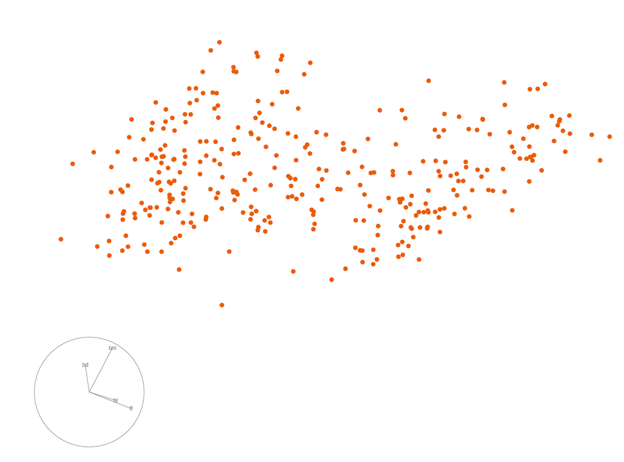

**Solution 6**

In the bottom left corner we see that `bm` and `fl` have the longest arrows which suggests that these two variables are projected the most in this view

5. Below is another screenshot taken from a tour of the penguins data. In this view of the tour we see evidence that there are at least two clusters in the data. Which variable appears to be driving the clustering structure that we see here the most?

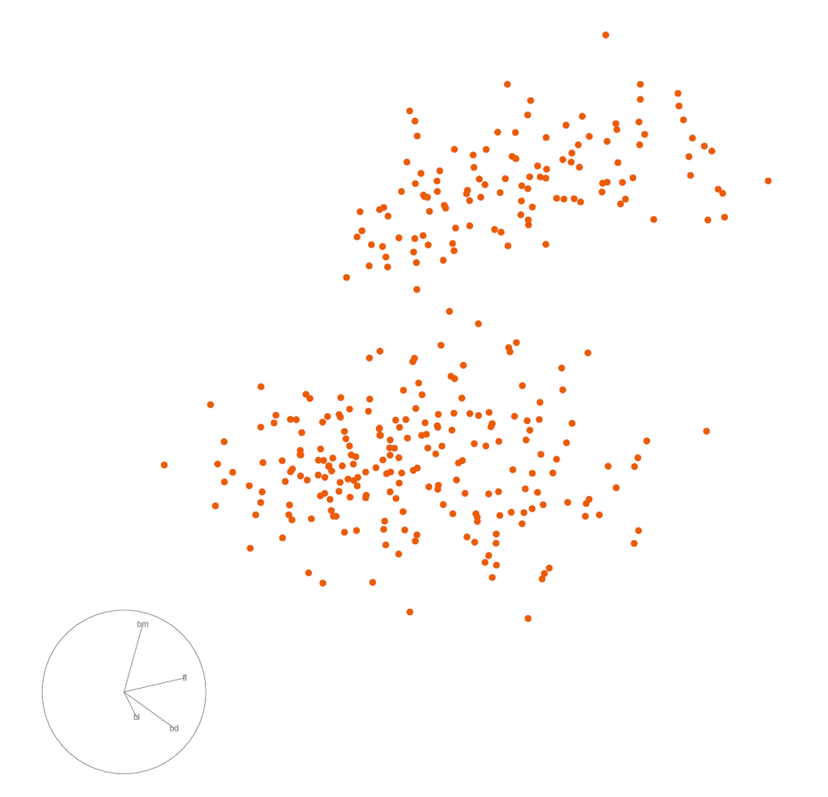

**Solution 7**

The clustering can be seen most along the vertical axis, with a slight tilt to the right. We see from the bottom left that variable `bm` is encoded to a large degree in this direction and so it is this variable that appears to be driving the clustering we see here.

#### 3. Detecting clusters

For the data sets, `c1`, `c3` from the `mulgar` package, use the grand tour to view and try to identify structure (outliers, clusters, non-linear relationships).

**Code to show in a tour**

```r
animate_xy(c1)
animate_xy(c3)
```

**Solution 8**

The first data set `c1` has 6 clusters, 4 small ones, and two big ones. The two big ones look like planes because they have no variation in some dimensions.

The second data set `c3` has a triangular prism shape, which itself is divided into several smaller triangular prisms. It also has several dimensions with no variation, because the points collapse into a line in some projections.

#### 4. Effect of covariance

Examine 5D multivariate normal samples drawn from populations with a range of variance-covariance matrices. (You can use the `mvtnorm` package to do the sampling, for example.) Examine the data using a grand tour. What changes when you change the correlation from close to zero to close to 1? Can you see a difference between strong positive correlation and strong negative correlation?

**Code to generate the samples**

```r
library(mvtnorm)
set.seed(501)

s1 <- diag(5)
s2 <- diag(5)
s2[3,4] <- 0.7
s2[4,3] <- 0.7
s3 <- s2
s3[1,2] <- -0.7
s3[2,1] <- -0.7

s1
```

```
     [,1] [,2] [,3] [,4] [,5]
[1,]    1    0    0    0    0
[2,]    0    1    0    0    0
[3,]    0    0    1    0    0
[4,]    0    0    0    1    0
[5,]    0    0    0    0    1
```

**Code to generate the samples**

```r
s2
```

```
     [,1] [,2] [,3] [,4] [,5]
[1,]    1    0  0.0  0.0    0
[2,]    0    1  0.0  0.0    0
[3,]    0    0  1.0  0.7    0
[4,]    0    0  0.7  1.0    0
[5,]    0    0  0.0  0.0    1
```

**Code to generate the samples**

```r
s3
```

```
     [,1] [,2] [,3] [,4] [,5]
[1,]  1.0 -0.7  0.0  0.0    0
[2,] -0.7  1.0  0.0  0.0    0
[3,]  0.0  0.0  1.0  0.7    0
[4,]  0.0  0.0  0.7  1.0    0
[5,]  0.0  0.0  0.0  0.0    1
```

**Code to generate the samples**

```r
set.seed(1234)
d1 <- as.data.frame(rmvnorm(500, sigma = s1))
d2 <- as.data.frame(rmvnorm(500, sigma = s2))
d3 <- as.data.frame(rmvnorm(500, sigma = s3))
```

**Solution 9**

```r
animate_xy(d1)
animate_xy(d2)
animate_xy(d3)
```

The points in data `d1` are pretty spread in every projection. For the data `d2`, `d3` have some projections where the data is concentrated along a line. This should be seen to be when variables 3 and 4 are contributing to the projection in `d2`, and when variables 1, 2, 3, 4 contributing to the projection in `d3`.

#### 5. Principal components analysis on the simulated data

🧐 For data sets `d2` and `d3` from Q4 what would you expect would be the number of PCs suggested by PCA?

👨🏽‍💻👩‍💻Conduct the PCA. Report the variances (eigenvalues), and cumulative proportions of total variance, make a scree plot, and the PC coefficients.

🤯Often, the selected number of PCs are used in future work. For both `d3` and `d4`, think about the pros and cons of using 4 PCs and 3 PCs, respectively.

**Solution 10**

Thinking about it: In `d2` there is strong correlation between variables 3 and 4, which means probably only 4PC s would be needed. In `d3` there is strong correlation also between variables 1 and 2 which would mean that only 3 PCs would be needed.

```r
d2_pca <- prcomp(d2, scale=TRUE)
d2_pca
```

```
Standard deviations (1, .., p=5):
[1] 1.2944925 1.0120246 0.9995775 0.9840652 0.5766767

Rotation (n x k) = (5 x 5):
           PC1         PC2          PC3         PC4         PC5
V1 0.009051897  0.60982755  0.600760775  0.51637067 -0.02182300
V2 0.042039564  0.44070702 -0.798335151  0.40808929  0.01158053
V3 0.702909484  0.03224989  0.034228444 -0.06034512  0.70715280
V4 0.702411571  0.03021836  0.002269932 -0.08050218 -0.70655437
V5 0.103377852 -0.65721722  0.023890154  0.74612487 -0.01027051
```

```r
d2_pca$sdev^2/5
```

```
[1] 0.33514216 0.20483875 0.19983102 0.19367686 0.06651121
```

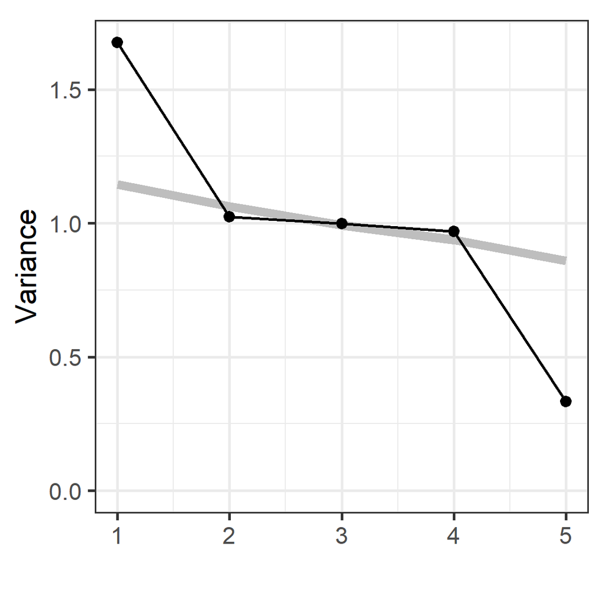

```r
mulgar::ggscree(d2_pca, q=5)
```

Four PCs explain 93% of the variation. PC1 is the combination of variables 3 and 4, which captures this reduced dimension.

```r
d3_pca <- prcomp(d3, scale=TRUE)
d3_pca
```

```
Standard deviations (1, .., p=5):
[1] 1.3262816 1.2831152 0.9984103 0.5561311 0.5371102

Rotation (n x k) = (5 x 5):
           PC1         PC2          PC3         PC4          PC5
V1  0.47372917  0.52551030  0.007091154 -0.55745578  0.434295265
V2 -0.49362867 -0.50367594 -0.047544823 -0.58444458  0.398503844
V3 -0.50057768  0.49960926  0.030888892 -0.40488840 -0.578726039
V4 -0.52968729  0.46318477  0.073441704  0.42649507  0.563559684
V5  0.02765464 -0.07745919  0.995661287 -0.04283613 -0.007678753
```

```r
d3_pca$sdev^2/5
```

```
[1] 0.35180458 0.32927695 0.19936462 0.06185637 0.05769748
```

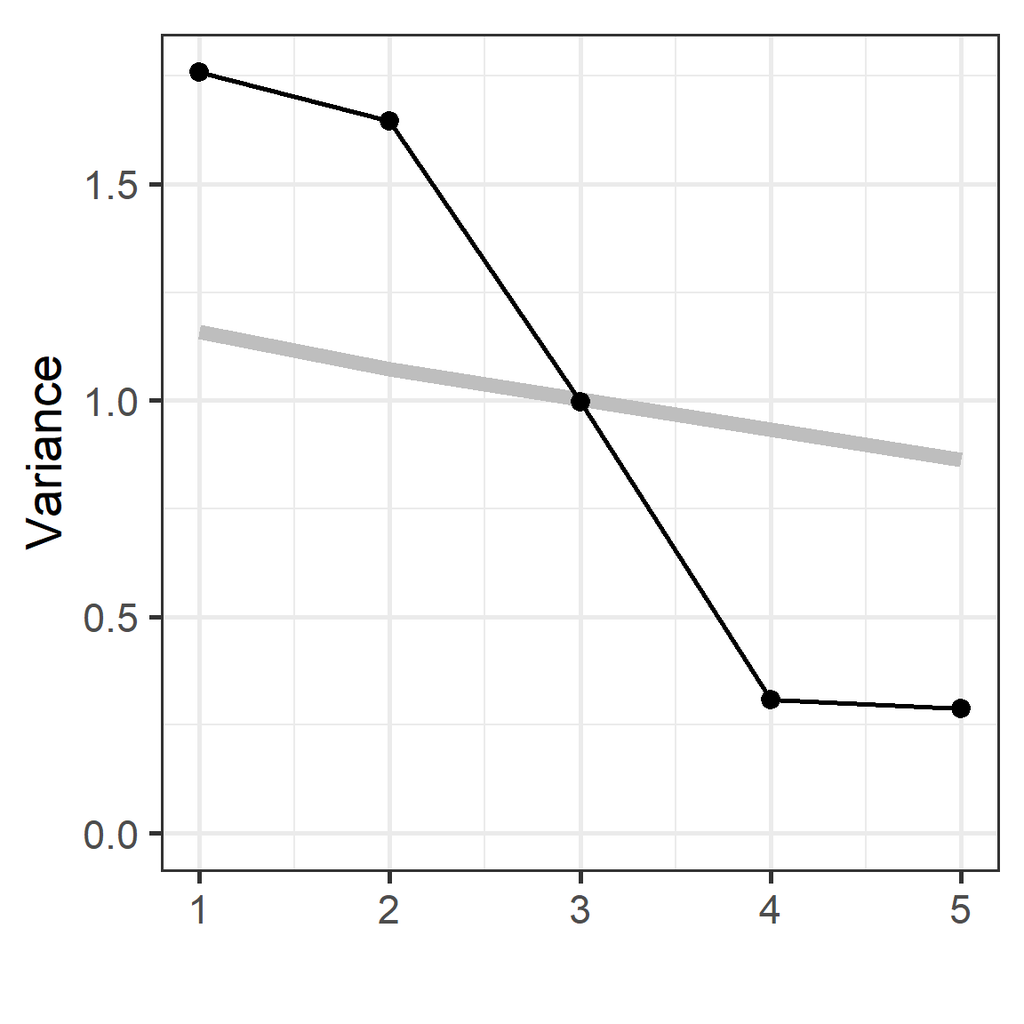

```r
mulgar::ggscree(d3_pca, q=5)
```

Three PCs explain 88% of the variation, and the last two PCs have much smaller variance than the others. PC 1 and 2 are combinations of variables 1, 2, 3 and 4, which captures this reduced dimension, and PC 3 is primarily variable 5.

The PCs are awkward combinations of the original variables. For `d2`, it would make sense to use PC1 (or equivalently and equal combination of V3, V4), and then keep the original variables V1, V2, V5.

For `d3` it’s harder to make this call because the first two PCs are combinations of four variables. Its hard to see from this that the ideal solution would be to use an equal combination of V1, V2, and equal combination of V3, V4 and V5 on its own.

Often understanding the variance that is explained by the PCs is hard to interpret.

#### 6. PCA on cross-currency time series

In Moodle, under Learning -> Getting Started you will find a data folder. Download this folder and you will it that contains the `rates_Nov19_Mar20.csv.csv` data.

The `rates_Nov19_Mar20.csv.csv` data has 152 currencies relative to the USD for the period of Nov 1, 2019 through to Mar 31, 2020. Treating the dates as variables, conduct a PCA to examine how the cross-currencies vary, focusing on this subset: ARS, AUD, BRL, CAD, CHF, CNY, EUR, FJD, GBP, IDR, INR, ISK, JPY, KRW, KZT, MXN, MYR, NZD, QAR, RUB, SEK, SGD, UYU, ZAR.

```r
rates <- read_csv("../data/rates_Nov19_Mar20.csv") |>
  select(date, ARS, AUD, BRL, CAD, CHF, CNY, EUR, FJD, GBP, IDR, INR, ISK, JPY, KRW, KZT, MXN, MYR, NZD, QAR, RUB, SEK, SGD, UYU, ZAR)
```

1. Standardise the currency columns to each have mean 0 and variance 1. Explain why this is necessary prior to doing the PCA or is it? Use this data to make a time series plot overlaying all of the cross-currencies.

**Code to standardise currencies**

```r
library(plotly)
rates_std <- rates |>
  mutate_if(is.numeric, function(x) (x-mean(x))/sd(x))
rownames(rates_std) <- rates_std$date
p <- rates_std |>
  pivot_longer(cols=ARS:ZAR,
               names_to = "currency",
               values_to = "rate") |>
  ggplot(aes(x=date, y=rate,
             group=currency, label=currency)) +
    geom_line()
#ggplotly(p, width=400, height=300)
p
```

**Solution 11**

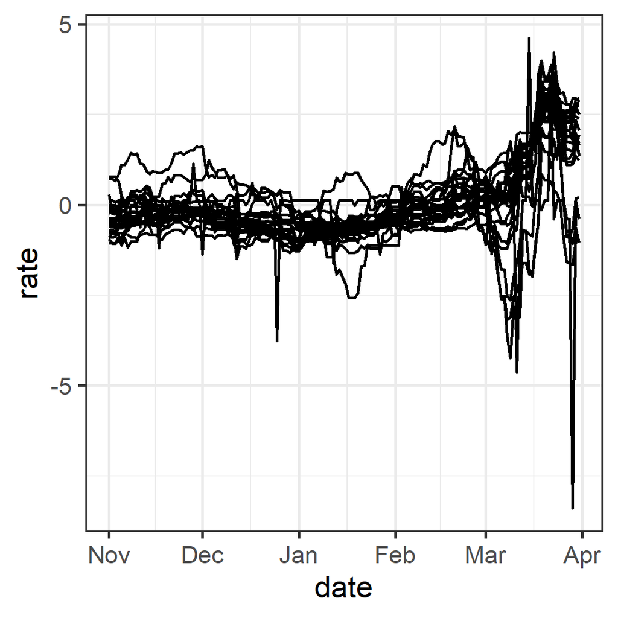

It isn’t necessary to standardise the variables before using the `prcomp` function because we can set `scale=TRUE` to have it done as part of the PCA computation. However, it is useful to standardise the variables to make the time series plot where all the currencies are drawn. This is useful for interpreting the principal components.

2. Conduct a PCA. Make a scree plot, and summarise proportion of the total variance. Summarise these values and the coefficients for the first five PCs, nicely.

**Code to do PCA and screeplot**

```r
rates_pca <- prcomp(rates_std[,-1], scale=FALSE)
mulgar::ggscree(rates_pca, q=24)
options(digits=2)
summary(rates_pca)
```

**Code to make a nice summary**

```r
# Summarise the coefficients nicely
rates_pca_smry <- tibble(evl=rates_pca$sdev^2) |>
  mutate(p = evl/sum(evl),
         cum_p = cumsum(evl/sum(evl))) |>
  t() |>
  as.data.frame()
colnames(rates_pca_smry) <- colnames(rates_pca$rotation)
rates_pca_smry <- bind_rows(as.data.frame(rates_pca$rotation),
                            rates_pca_smry)
rownames(rates_pca_smry) <- c(rownames(rates_pca$rotation),
                              "Variance", "Proportion",
                              "Cum. prop")
rates_pca_smry[,1:5]
```

**Solution 12**

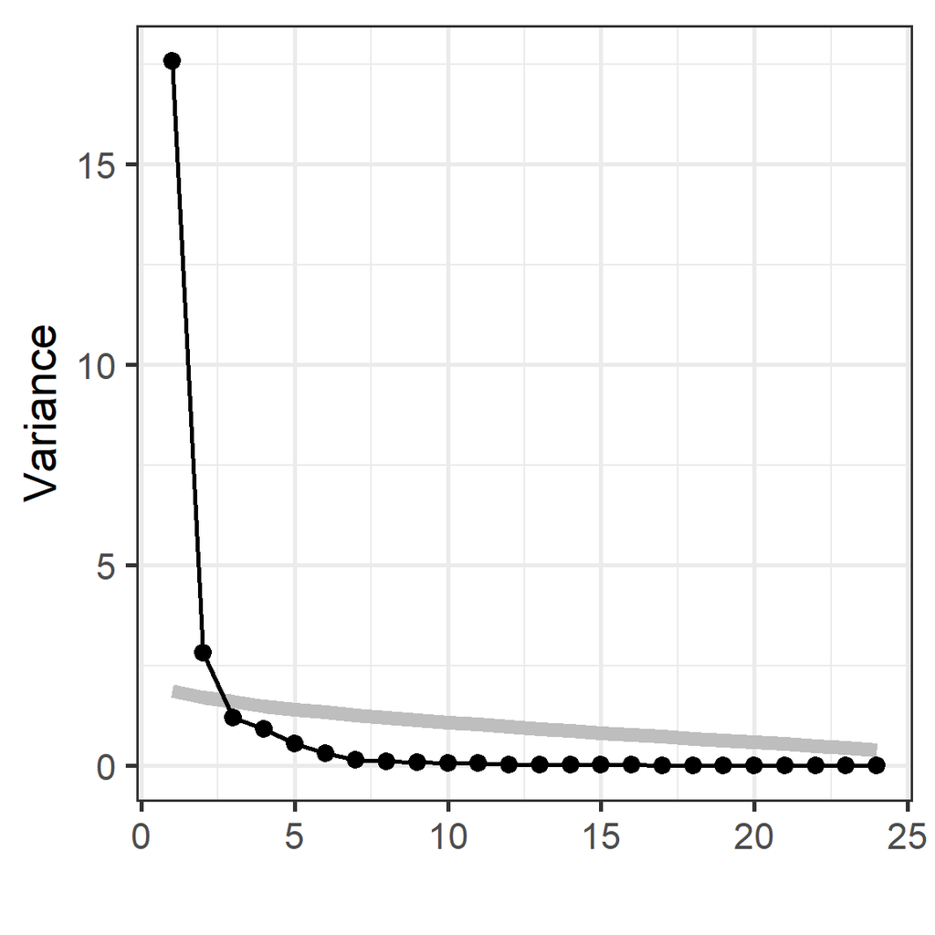

```
Importance of components:
                         PC1   PC2    PC3    PC4    PC5    PC6     PC7     PC8
Standard deviation     4.193 1.679 1.0932 0.9531 0.7358 0.5460 0.38600 0.33484
Proportion of Variance 0.733 0.118 0.0498 0.0379 0.0226 0.0124 0.00621 0.00467
Cumulative Proportion  0.733 0.850 0.8999 0.9377 0.9603 0.9727 0.97893 0.98360
                           PC9    PC10    PC11    PC12    PC13    PC14    PC15
Standard deviation     0.30254 0.25669 0.25391 0.17893 0.16189 0.15184 0.14260
Proportion of Variance 0.00381 0.00275 0.00269 0.00133 0.00109 0.00096 0.00085
Cumulative Proportion  0.98741 0.99016 0.99284 0.99418 0.99527 0.99623 0.99708
                          PC16    PC17    PC18    PC19    PC20    PC21    PC22
Standard deviation     0.11649 0.10691 0.09923 0.09519 0.08928 0.07987 0.07222
Proportion of Variance 0.00057 0.00048 0.00041 0.00038 0.00033 0.00027 0.00022
Cumulative Proportion  0.99764 0.99812 0.99853 0.99891 0.99924 0.99950 0.99972
                          PC23    PC24
Standard deviation     0.05985 0.05588
Proportion of Variance 0.00015 0.00013
Cumulative Proportion  0.99987 1.00000
```

```
              PC1    PC2      PC3    PC4     PC5
ARS         0.215 -0.121  0.19832  0.181 -0.2010
AUD         0.234  0.013  0.11466  0.018  0.0346
BRL         0.229 -0.108  0.10513  0.093 -0.0526
CAD         0.235 -0.025 -0.02659 -0.037  0.0337
CHF        -0.065  0.505 -0.33521 -0.188 -0.0047
CNY         0.144  0.237 -0.45337 -0.238 -0.5131
EUR         0.088  0.495  0.24474  0.245 -0.1416
FJD         0.234  0.055  0.04470  0.028  0.0330
GBP         0.219  0.116 -0.00915 -0.073  0.3059
IDR         0.218 -0.022 -0.24905 -0.117  0.2362
INR         0.223 -0.147 -0.00734 -0.014  0.0279
ISK         0.230 -0.016  0.10979  0.093  0.1295
JPY        -0.022  0.515  0.14722  0.234  0.3388
KRW         0.214  0.063  0.17488  0.059 -0.3404
KZT         0.217  0.013 -0.23244 -0.119  0.3304
MXN         0.229 -0.059 -0.13804 -0.102  0.2048
MYR         0.227  0.040 -0.13970 -0.115 -0.2009
NZD         0.230  0.061  0.04289 -0.056 -0.0354
QAR        -0.013  0.111  0.55283 -0.807  0.0078
RUB         0.233 -0.102 -0.05863 -0.042  0.0063
SEK         0.205  0.240  0.07570  0.085  0.0982
SGD         0.227  0.057  0.14225  0.115 -0.2424
UYU         0.231 -0.101  0.00064 -0.053  0.0957
ZAR         0.232 -0.070 -0.00328  0.042 -0.0443
Variance   17.582  2.820  1.19502  0.908  0.5413
Proportion  0.733  0.118  0.04979  0.038  0.0226
Cum. prop   0.733  0.850  0.89989  0.938  0.9603
```

- The first two principal components explain 85% of the total variation.
- PC1 is a combination of all of the currencies except for CHF, EUR, JPY, QAR.
- PC2 is a combination of CHF, EUR, JPY.
3. Make a biplot of the first two PCs. Explain what you learn.

**Biplot code**

```r
library(ggfortify)
autoplot(rates_pca, loadings = TRUE,
         loadings.label = TRUE)
```

**Solution 13**

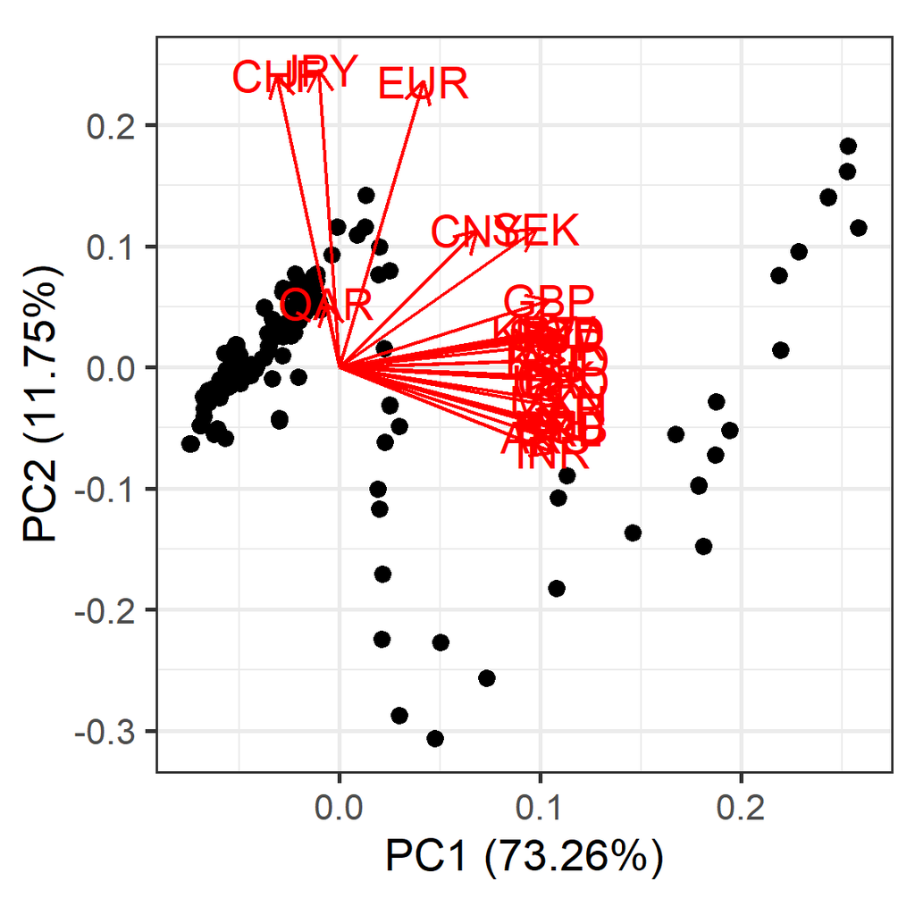

- Most of the currencies contribute substantially to PC1. Only three contribute strongly to PC2: CHF, JPY, EUR. Similar to what is learned from the summary table (made in b).
- The pattern of the points is most unusual! It has a curious S shape. Principal components are supposed to be a random scattering of values, with no obvious structure. This is a very strong pattern.
4. Make a time series plot of PC1 and PC2. Explain why this is useful to do for this data.

**Code to plot PCs**

```r
rates_pca$x |>
  as.data.frame() |>
  mutate(date = rates_std$date) |>
  ggplot(aes(x=date, y=PC1)) + geom_line()

rates_pca$x |>
  as.data.frame() |>
  mutate(date = rates_std$date) |>
  ggplot(aes(x=date, y=PC2)) + geom_line()
```

**Solution 14**

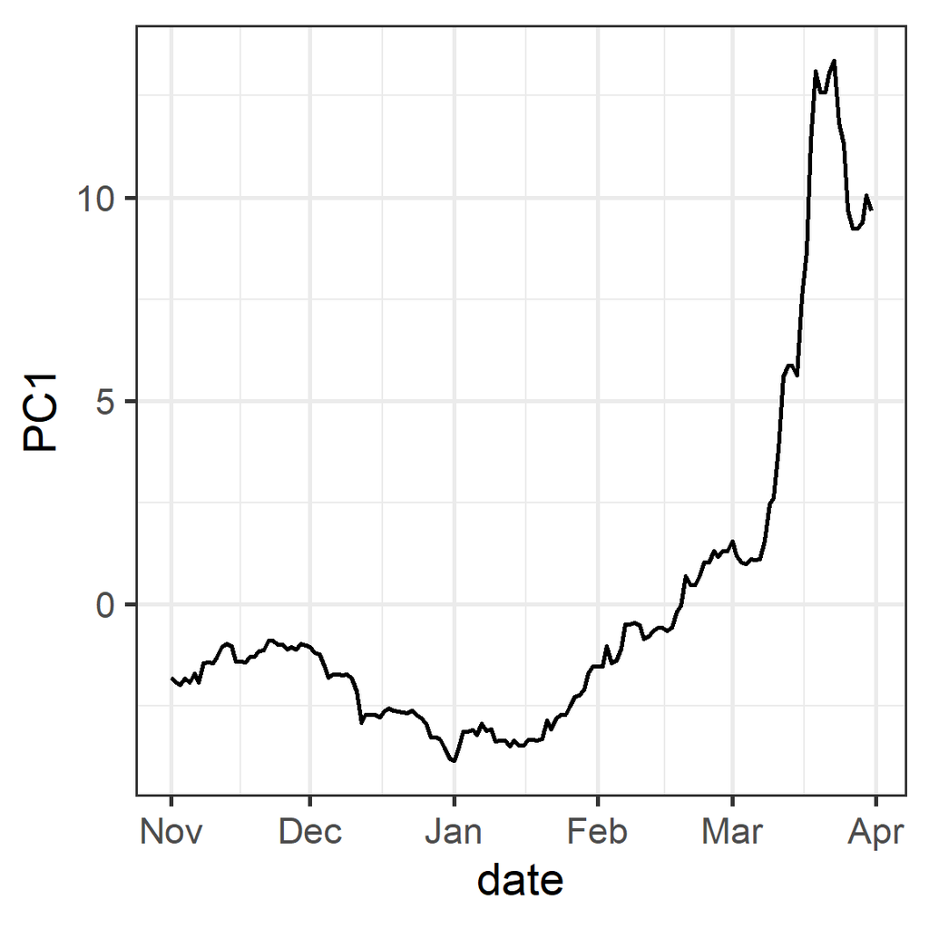

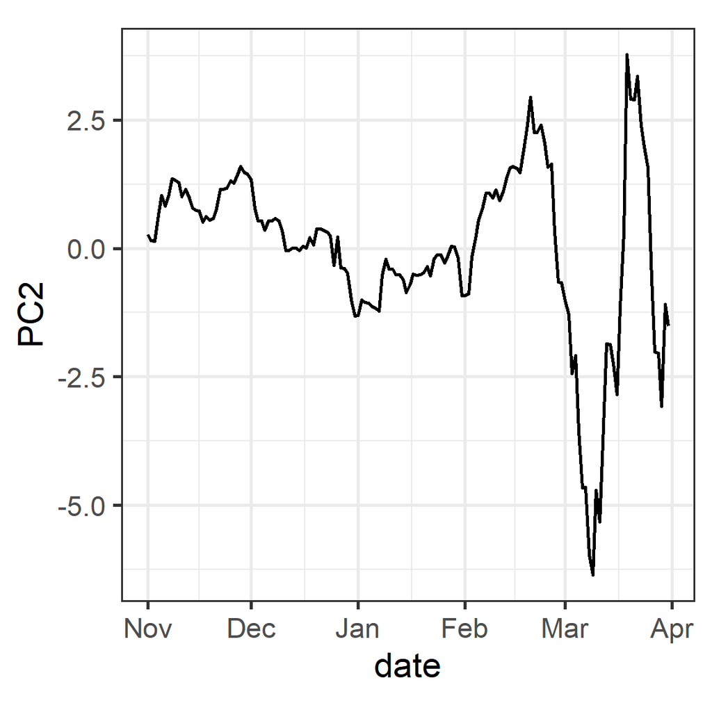

- Because there is a strong pattern in the first two PCs, it could be useful to understand if this is related to the temporal context of the data.
- Here we might expect that the PCs extract the main temporal patterns. We see this is the case.
- PC1 reflects the large group of currencies that greatly increase in mid-March.
- PC2 reflects the few currencies that decrease at the start of March.

Note that: increase here means that the value of the currency declines relative to the USD and a decrease indicates stronger relative to the USD. *Is this correct?*

5. You’ll want to drill down deeper to understand what the PCA tells us about the movement of the various currencies, relative to the USD, over the volatile period of the COVID pandemic. Plot the first two PCs again, but connect the dots in order of time. Make it interactive with plotly, where the dates are the labels. What does following the dates tell us about the variation captured in the first two principal components?

**Code to use interaction of the PC plot**

```r
library(plotly)
p2 <- rates_pca$x |>
  as.data.frame() |>
  mutate(date = rates_std$date) |>
  ggplot(aes(x=PC1, y=PC2, label=date)) +
    geom_point() +
    geom_path()
#ggplotly(p2, width=400, height=400)
p2
```

**Solution 15**

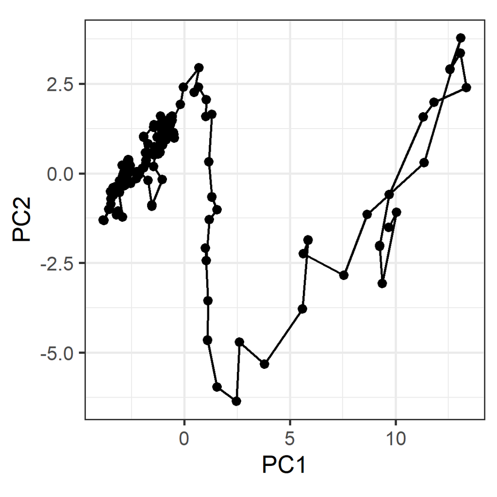

The pattern in PC1 vs PC2 follows time. Prior to the pandemic there is a tangle of values on the left. Towards the end of February, when the world was starting to realise that COVID was a major health threat, there is a dramatic reaction from the world currencies, at least in relation to the USD. Currencies such as EUR, JPY, CHF reacted first, gaining strength relative to USD, and then they lost that strength. Most other currencies reacted later, losing value relative to the USD.

#### 7. Write a simple question about the week’s material and test your neighbour, or your tutor.

## 👋 Finishing up

Make sure you say thanks and good-bye to your tutor. This is a time to also report what you enjoyed and what you found difficult.